# MPDW Praktikum 4

Author

Yehezki Novandri Liman

# Proses MA(2)

Proses MA(2) dapat dituliskan sebagai berikut:

$$y_{t} = c + e_t + \theta_{1}e_{t-1} + \theta_{2}e_{t-2}$$

## Pembangkitan Proses MA(2)

Membangkitkan model MA(2) dengan $\theta_1 = 0.4$ dan $\theta_2 = 0.6$ sebanyak 300 observasi dengan $c=0$. Bangkitkan nilai pertama dan kedua terlebih dahulu menggunakan white noise, kemudian nilai-nilai selanjutnya dicari dengan melakukan looping pada rumus MA(2) dibawah.

$$y_{t} = e_t + 0,4e_{t-1} + 0.6e_{t-2}$$

### Manual

```r
set.seed(1234)
wn <- rnorm(300)
ma <- wn[1:2]
for(i in 3:300){
   ma[i] <- wn[i] + 0.4 * wn[i - 1] + 0.6 * wn[i - 2]
}
ma
```

```
  [1] -1.207065749  0.277429242  0.471173424 -1.745463687  0.141510314
  [6] -0.729712854 -0.114842790 -0.472894305 -1.127948717 -1.443797742
 [11] -1.171879031 -1.723286222 -1.461924092 -0.845074607  0.519525249
 [16]  0.312187420  0.020572732 -1.181770516 -1.508255550  1.534249256
 [21]  0.598119283  1.012450498 -0.556369299 -0.011041246 -0.774213194
 [26] -1.449939345 -0.420758391 -1.662676381 -0.079747157 -1.556197355
 [31]  0.718835126 -0.596243221 -0.238298741 -1.070389923 -2.255260716
 [36] -2.120011486 -3.624543435 -2.913580609 -2.138714925 -1.388210999
 [41]  1.086560934 -0.768382742 -0.413123964 -1.263954490 -1.619808057
 [46] -1.534624150 -2.091327966 -2.276021753 -1.689013389 -1.457572736
 [51] -2.319068111 -1.602598402 -2.425338748 -1.807763414 -1.233628102
 [56] -0.110845196  1.775654086  0.223607057  2.285258743 -0.979456751
 [61]  1.157010823  2.116941328  1.378789117  0.845856907 -0.296314421
 [66]  1.372262398 -0.432336811  1.978634754  1.193531021  1.688995021
 [71]  0.939220832 -0.250827924 -0.544575725  0.228395751  2.109671129
```

[output cut: 45 more lines]

### arima.sim

Selain menggunakan cara manual, pembangkitan proses MA(2) dapat dilakukan dengan fungsi `arima.sim()` sebagai berikut.

```r
ma1 <- arima.sim(list(order=c(0,0,2), ma=c(0.4,0.6)), n=300)
ma1
```

```
Time Series:
Start = 1
End = 300
Frequency = 1
  [1] -0.908714261  0.366069559  0.319892749 -0.033692645 -0.749809541
  [6]  1.023224875 -0.103827746  1.553027734  1.508813504  1.490258435
 [11]  0.638775303  0.057508568 -0.761313741  1.006804154  0.046165301
 [16]  2.226792228 -0.031351321  0.058227766 -0.452682262 -0.306828839
 [21] -0.408896770 -1.768664231 -0.905163217 -1.653388217  0.814020129
 [26] -0.949587092  1.394975120 -0.770061199  0.708742509  0.626264945
 [31]  0.016220780  0.886163244 -0.177443664 -0.837739266 -0.776948985
 [36]  0.830630275  0.271737011  0.068438994 -0.509614613 -0.182137038
 [41]  1.054967504  1.724174690  1.131301118  1.891160132 -0.238116411
 [46] -1.951472236 -1.868044756 -2.111236903 -2.805388403 -0.673455997
 [51] -1.948408128 -0.202080988 -2.147789666 -0.222949385  1.157974906
```

[output cut: 49 more lines]

Kita akan mencoba melakukan pengecekan karakteristik melalui visualisasi plot, scatterplot, dan menghitung autokorelasi menggunakan data yang dibangkitkan dengan cara manual.

## Pembuatan Plot untuk MA(2)

### Plot Time Series

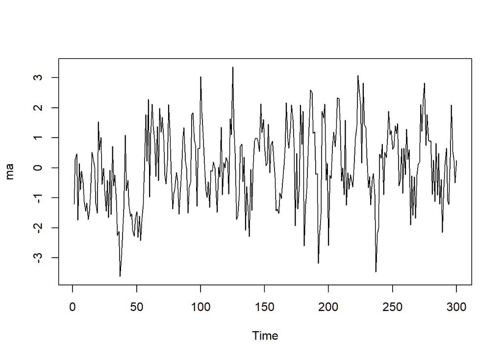

```r
ts.plot(ma)
```

Berdasarkan plot time series tersebut, dapat dilihat bahwa data proses MA(2) yang telah dibangkitkan stasioner dalam rataan.

### Plot ACF

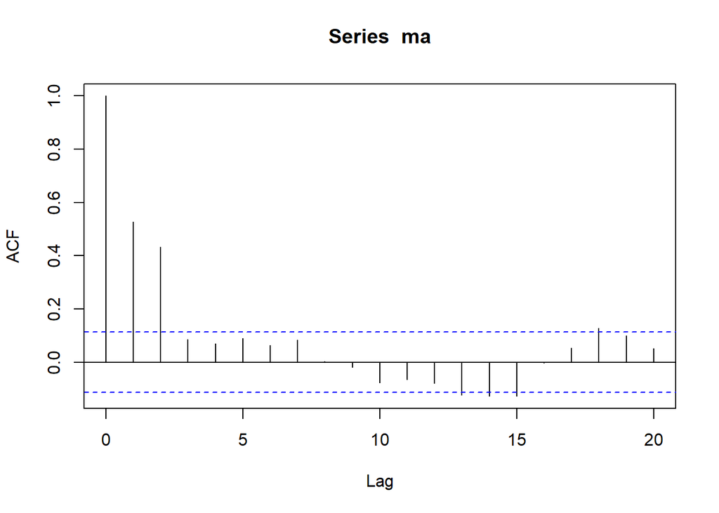

```r
acf(ma,lag.max = 20)
```

Berdasarkan plot ACF yang disajikan, terlihat bahwa plot ACF mengalami cut off pada lag kedua.

### Plot PACF

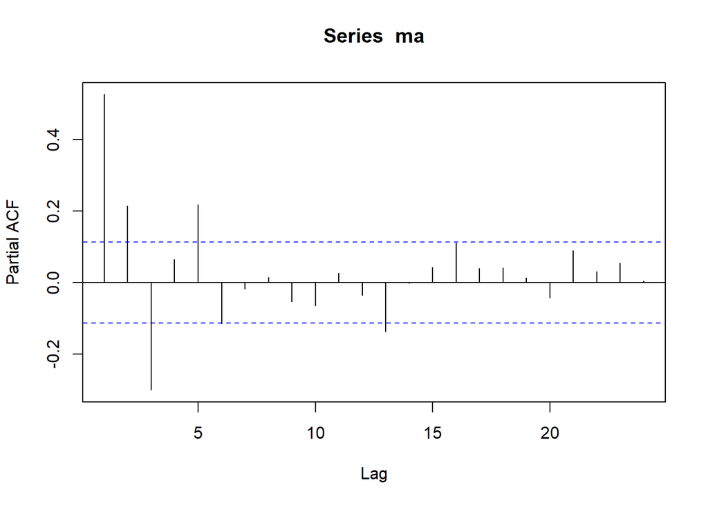

```r
pacf(ma)
```

Berdasarkan plot PACF diatas, terlihat bahwa plot PACF mengalami tails off dengan pola sinus yang perlahan mengecil. Berdasarkan plot ACF dan PACF, maka data MA(2) stasioner.

### Plot EACF

```r
TSA::eacf(ma)
```

```
AR/MA
  0 1 2 3 4 5 6 7 8 9 10 11 12 13
0 x x o o o o o o o o o  o  x  x
1 x x x o o o o o o o o  o  o  o
2 x x x x o o o o o o o  o  o  o
3 x x x x x o o o o o o  o  o  o
4 x x x x x o o o o o o  o  o  o
5 x x x x x o x o o o o  o  o  o
6 x x x o x o o x o o o  o  o  o
7 x o x o x o o x o o o  o  o  o
```

Berdasarkan pola segitiga nol pada plot EACF, dapat digambarkan bahwa segitiga nol berada pada ordo AR(0) dan MA(2).

## Scatterplot dan Korelasi Antar Lag

### Scatterplot dan Korelasi antara $Y_t$ dengan $Y_{t-1}$

```r
yt_ma <- ma[-1] #Yt
yt_1_ma <- ma[-300] #Yt-1
```

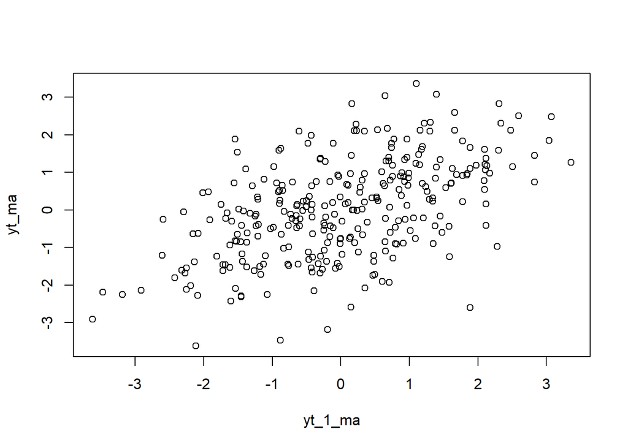

```r
plot(y=yt_ma,x=yt_1_ma)
```

Berdasarkan scatterplot tersebut, terlihat bahwa terdapat hubungan positif antara $Y_t$ dengan $Y_{t-1}$.

```r
cor(yt_ma,yt_1_ma)
```

```
[1] 0.5274606
```

Korelasi antara $Y_t$ dengan $Y_{t-1}$ dari hasil simulasi adalah 0.5274. Selanjutnya, akan dilakukan perhitungan korelasi teoritis yang akan mendekati nilai korelasi simulasi sebagai berikut:

$$\rho_1=\frac{\theta_1(1+\theta_2)}{1+\theta_1^2+\theta_2^2}=\frac{0.4(1+0.6)}{1+(0.4)^2+(0.6)^2}=0.421$$

### Scatterplot dan Korelasi antara $Y_t$ dengan $Y_{t-2}$

```r
yt_ma2 <- ma[-c(1,2)] #Yt
yt_2_ma <- ma[-c(299,300)] #Yt-2
```

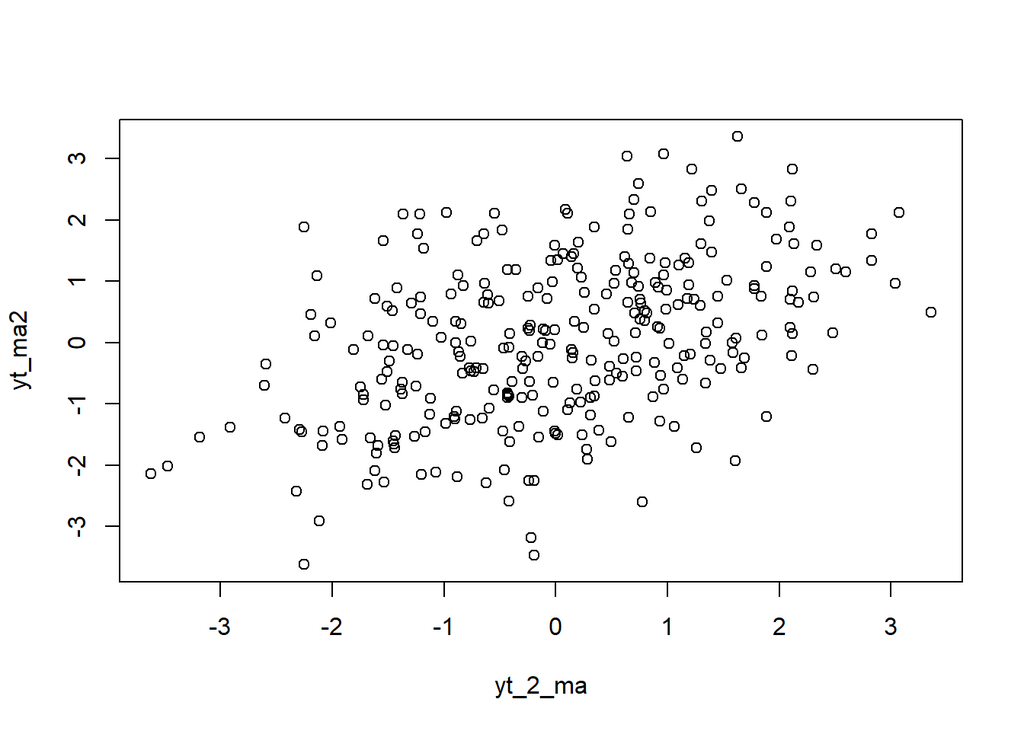

```r
plot(y=yt_ma2,x=yt_2_ma)
```

Berdasarkan scatterplot tersebut, terlihat bahwa terdapat hubungan positif yang melemah antara $Y_t$ dengan $Y_{t-2}$.

```r
cor(yt_ma2,yt_2_ma)
```

```
[1] 0.4339293
```

### Scatterplot dan Korelasi antara $Y_t$ dengan $Y_{t-3}$

```r
yt_ma3 <- ma[-c(1,2,3)] #Yt
yt_3_ma <- ma[-c(298,299,300)] #Yt-3
```

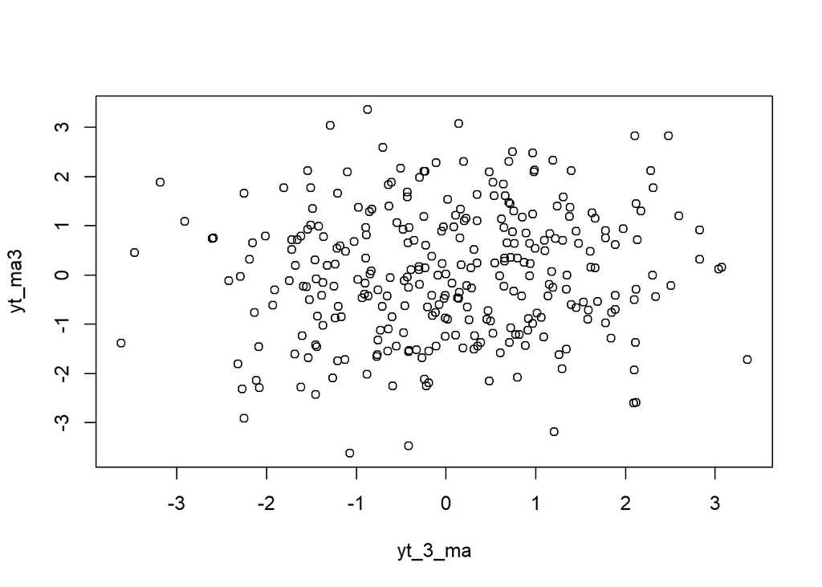

```r
plot(y=yt_ma3,x=yt_3_ma)
```

Berdasarkan scatterplot tersebut, terlihat bahwa cenderung tidak terdapat hubungan antara $Y_t$ dengan $Y_{t-3}$.

```r
cor(yt_ma3,yt_3_ma)
```

```
[1] 0.08555282
```

Korelasi antara $Y_t$ dengan $Y_{t-3}$ hasil simulasi mendekati teori yang ada yaitu 0.

# Proses AR(2)

Proses AR(2) dapat dituliskan sebagai berikut:

$$y_{t} = c + e_t + \phi_{1}Y_{t-1} + \phi_{2}Y_{t-2}$$

## Pembangkitan Proses AR(2)

Membangkitkan model AR(2) dengan $\phi_1 = 0.5$ dan $\phi_2 = 0.2$ sebanyak 300 observasi dengan $c=0$. Bangkitkan nilai pertama dan kedua terlebih dahulu menggunakan white noise, kemudian nilai-nilai selanjutnya dicari dengan melakukan looping pada rumus MA(2) dibawah.

$$y_{t} = e_t + 0.5Y_{t-1} + 0.2Y_{t-2}$$

### Manual

```r
set.seed(1234)
ar <- wn[1:2]
for(i in 3:300){
   ar[i] <- wn[i] + 0.5 * ar[i - 1] + 0.2 * ar[i - 2]
}
ar
```

```
  [1] -1.207065749  0.277429242  0.981742648 -1.799340530 -0.274197047
  [6]  0.009089263 -0.625034738 -0.857331372 -1.118124633 -1.620566420
 [11] -1.511100836 -2.078050147 -2.117499135 -1.409900780 -0.168956158
 [16] -0.476743729 -0.783172602 -1.398130464 -1.692871432  1.289773370
 [21]  0.440400618 -0.012530914 -0.358733205  0.277716656 -0.626608560
 [26] -1.705965859 -0.403548921 -1.566623355 -0.879159762 -1.688853153
 [31]  0.082039017 -0.772344201 -1.079204335 -1.195329068 -2.442598870
 [36] -2.627984511 -3.982551678 -3.857865933 -3.019737161 -2.747339308
 [41] -0.528120821 -1.882170996 -1.902074296 -1.608094349 -2.178802110
 [46] -2.379534243 -2.732845736 -3.094315602 -2.617555067 -2.424490611
 [51] -3.541787576 -2.837867835 -3.236181057 -3.200626105 -2.409858787
 [56] -1.281998796  0.524846317 -0.767330024  1.327213880 -0.647667612
 [61]  0.598197434  2.718556265  1.444157230  0.596156288  0.579304834
 [66]  2.185968123  0.070237292  1.840139450  2.263681974  1.836341674
 [71]  1.377800070  0.600699632  0.209385897  0.873119442  2.548707762
```

[output cut: 45 more lines]

### arima.sim

Selain menggunakan cara manual, pembangkitan proses AR(2) dapat dilakukan dengan fungsi `arima.sim()` sebagai berikut.

```r
ar1 <- arima.sim(list(order=c(2,0,0), ar=c(0.5,0.2)), n=300)
ar1
```

```
Time Series:
Start = 1
End = 300
Frequency = 1
  [1] -1.7066325607 -0.4040571790 -1.5670108246 -0.8794551485 -1.6890783403
  [6]  0.0818673463 -0.7724750738 -1.0793041051 -1.1954051279 -2.4426568541
 [11] -2.6280287147 -3.9825853771 -3.8578916236 -3.0197567460 -2.7473542381
 [16] -0.5281322030 -1.8821796728 -1.9020809107 -1.6080993919 -2.1788059544
 [21] -2.3795371734 -2.7328479702 -3.0943173054 -2.6175563658 -2.4244916012
 [26] -3.5417883306 -2.8378684102 -3.2361814957 -3.2006264394 -2.4098590424
 [31] -1.2819989901  0.5248461693 -0.7673301373  1.3272137941 -0.6476676781
 [36]  0.5981973841  2.7185562271  1.4441572006  0.5961562661  0.5793048174
 [41]  2.1859681101  0.0702372818  1.8401394423  2.2636819683  1.8363416698
 [46]  1.3778000670  0.6006996293  0.2093858952  0.8731194410  2.5487077608
 [51]  1.2955793561 -0.2331697165 -0.5810507641 -0.0788975632 -0.4727180494
```

[output cut: 49 more lines]

Kita akan mencoba melakukan pengecekan karakteristik melalui visualisasi plot, scatterplot, dan menghitung autokorelasi menggunakan data yang dibangkitkan dengan cara manual.

## Pembuatan Plot untuk AR(2)

### Plot Time Series

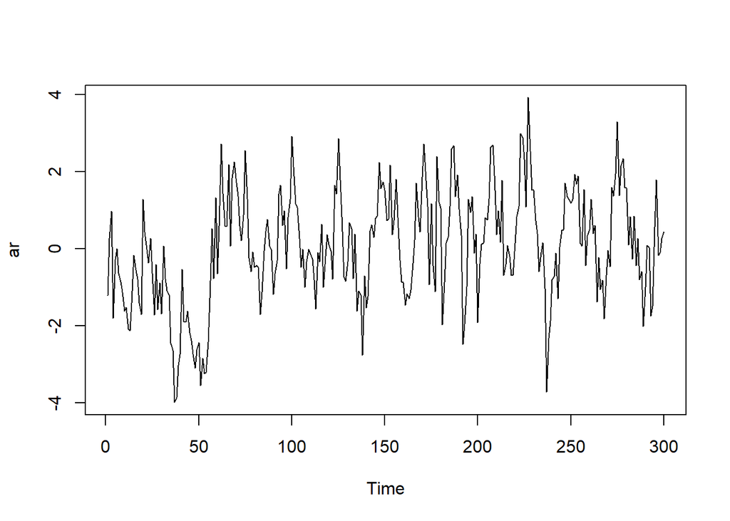

```r
ts.plot(ar)
```

Berdasarkan plot time series tersebut, dapat dilihat bahwa data proses AR(2) yang telah dibangkitkan stasioner dalam rataan.

### Plot ACF

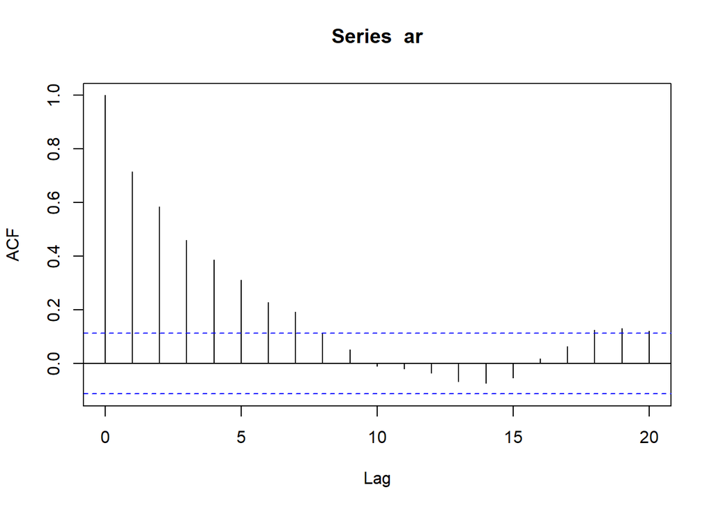

```r
acf(ar,lag.max = 20)
```

Berdasarkan plot ACF yang disajikan, terlihat bahwa plot ACF cenderung tails off membentuk pola grafik sinus yang perlahan mengecil.

### Plot PACF

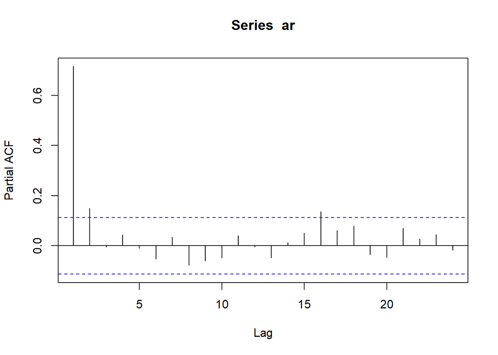

```r
pacf(ar)
```

Berdasarkan plot PACF diatas, terlihat bahwa plot PACF mengalami cut off pada lag kedua. Berdasarkan plot ACF dan PACF, maka data AR(2) stasioner.

### Plot EACF

```r
TSA::eacf(ar)
```

```
AR/MA
  0 1 2 3 4 5 6 7 8 9 10 11 12 13
0 x x x x x x x o o o o  o  o  o
1 x o o o o o o o o o o  o  o  o
2 o o o o o o o o o o o  o  o  o
3 x x o o o o o o o o o  o  o  o
4 x x o o o o o o o o o  o  o  o
5 x x o x o o x o o o o  o  o  o
6 x x x x o o o o o o o  o  o  o
7 x x x o x x o o o o o  o  o  o
```

Berdasarkan pola segitiga nol pada plot EACF, dapat digambarkan bahwa segitiga nol condong berada pada ordo AR(2) dan MA(1).

## Scatterplot dan Korelasi Antar Lag

### Scatterplot dan Korelasi antara $Y_t$ dengan $Y_{t-1}$

```r
yt_ar <- ar[-1] #Yt
yt_1_ar <- ar[-300] #Yt-1
```

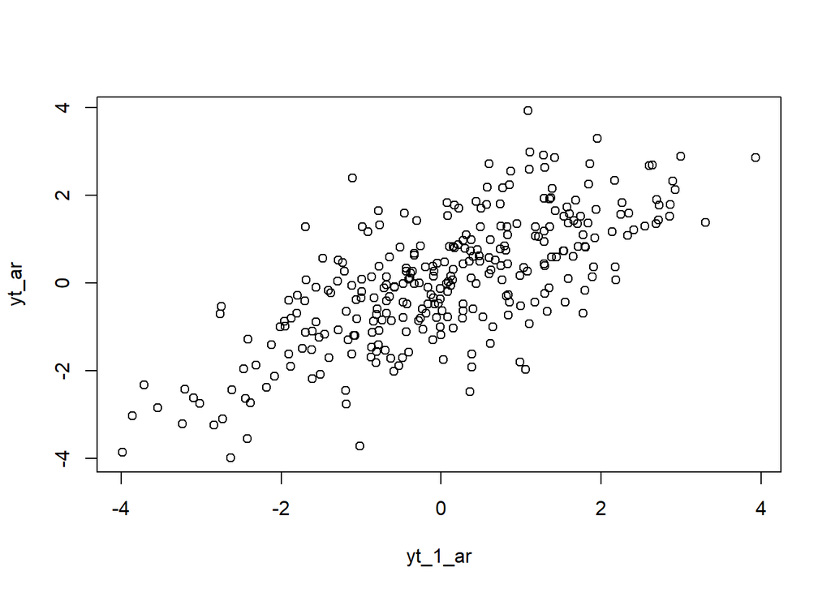

```r
plot(y=yt_ar,x=yt_1_ar)
```

Berdasarkan scatterplot tersebut, terlihat bahwa terdapat hubungan positif yang kuat antara $Y_t$ dengan $Y_{t-1}$.

```r
cor(yt_ar,yt_1_ar)
```

```
[1] 0.7165728
```

Korelasi antara $Y_t$ dengan $Y_{t-1}$ dari hasil simulasi adalah 0.7165. Selanjutnya, akan dilakukan perhitungan korelasi teoritis yang akan mendekati nilai korelasi simulasi sebagai berikut:

$$\rho_1=\frac{\phi_1}{1-\phi_2}=\frac{0.5}{1-0.2}=0.625$$

### Scatterplot dan Korelasi antara $Y_t$ dengan $Y_{t-2}$

```r
yt_ar2 <- ar[-c(1,2)] #Yt
yt_2_ar <- ar[-c(299,300)] #Yt-2
```

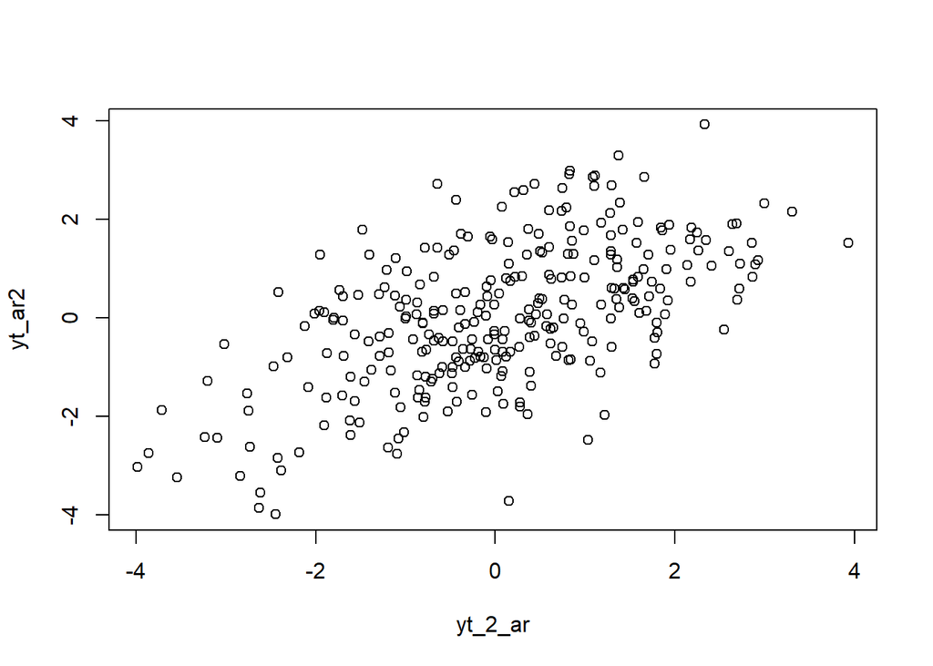

```r
plot(y=yt_ar2,x=yt_2_ar)
```

Berdasarkan scatterplot tersebut, terlihat bahwa terdapat hubungan positif yang kuat antara $Y_t$ dengan $Y_{t-2}$.

```r
cor(yt_ar2,yt_2_ar)
```

```
[1] 0.5856318
```

Korelasi antara $Y_t$ dengan $Y_{t-2}$ dari hasil simulasi adalah 0.5856. Selanjutnya, akan dilakukan perhitungan korelasi teoritis yang akan mendekati nilai korelasi simulasi sebagai berikut:

$$\rho_2=\frac{\phi_1^2}{1-\phi_2}+\phi_2=\frac{0.5^2}{1-0.2}+0.2=0.5125$$

### Scatterplot dan Korelasi antara $Y_t$ dengan $Y_{t-3}$

```r
yt_ar3 <- ar[-c(1,2,3)] #Yt
yt_3_ar <- ar[-c(298,299,300)] #Yt-3
```

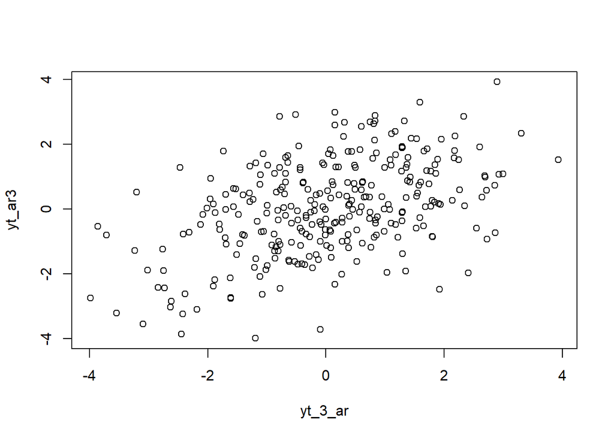

```r
plot(y=yt_ar3,x=yt_3_ar)
```

Berdasarkan scatterplot tersebut, terlihat bahwa terdapat hubungan positif yang mulai melemah antara $Y_t$ dengan $Y_{t-3}$.

```r
cor(yt_ar3,yt_3_ar)
```

```
[1] 0.4609517
```

Korelasi antara $Y_t$ dengan $Y_{t-3}$ dari hasil simulasi adalah 0.4609. Selanjutnya, akan dilakukan perhitungan korelasi teoritis yang akan mendekati nilai korelasi simulasi sebagai berikut:

$$\rho_3=\phi_1\rho_2+\phi_2\rho_1=0.5(0.5125)+0.2(0.625)=0.3812$$

# Proses ARMA(2,2)

Proses ARMA(2,2) dapat dituliskan sebagai berikut:

$$y_{t} = c + \phi_1y_{t-1} + \phi_2y_{t-2} + e_t + \theta_1e_{t-1}+ \theta_2e_{t-2}$$

## Pembangkitan Proses ARMA(2,2)

Membangkitkan model ARMA(2,2) dengan $\theta_1 = 0.4, \theta_2 = 0.6, \phi_1 = 0.5$ dan $\phi_2 = 0.2$ sebanyak 300 observasi dengan $c=0$. Bangkitkan nilai pertama dan kedua terlebih dahulu menggunakan white noise, kemudian nilai-nilai selanjutnya dicari dengan melakukan looping pada rumus ARMA(2,2) dibawah.

$$y_{t} = 0.5y_{t-1} + 0.2y_{t-2} + e_t + 0.4e_{t-1}+ 0.6e_{t-2}$$

### Manual

```r
n = length(wn)
phi1 = 0.5
phi2 = 0.2
theta1 = 0.4
theta2 = 0.6

arma=wn[1:2]
for (i in 3:n){
  arma[i] = phi1*arma[i-1] + phi2*arma[i-2] + theta1*wn[i-1] + theta2*wn[i-2] + wn[i]
  }
arma
```

```
  [1] -1.20706575  0.27742924  0.36847490 -1.50574039 -0.53766490 -1.29969338
  [7] -0.87222246 -1.16894421 -1.88686532 -2.62101924 -2.85976172 -3.67737093
 [13] -3.87256190 -3.51682974 -2.01340200 -1.39787953 -1.08104743 -2.00187014
 [19] -2.72540011 -0.22882482 -0.06137315  0.93599896 -0.10064445  0.12583632
 [25] -0.73142392 -1.79048404 -1.46228520 -2.75191579 -1.74816209 -2.98066156
 [31] -1.12112807 -1.75293957 -1.33899414 -2.09047491 -3.56829700 -4.32225497
 [37] -6.49933032 -7.02769676 -6.95242937 -6.26996504 -3.43890746 -3.74182948
 [43] -2.97182019 -3.49823048 -3.96328734 -4.21591391 -4.99194239 -5.61517573
 [49] -5.49498973 -5.32810275 -6.08211743 -5.70927767 -6.49640107 -6.19781948
 [55] -5.63181806 -4.16631812 -1.43386859 -1.32659086  1.33518960 -0.57718012
 [61]  1.13545868  2.56923464  2.89049817  2.80495292  1.68426167  2.77538382
 [67]  1.29220743  3.17981523  3.04188012  3.84589813  3.47054592  2.25362466
 [73]  1.27634579  1.31729358  3.02358708  2.83893413  1.81428668  0.10302896
 [79] -0.45121970 -0.85290753 -0.66635425 -0.93510416 -2.14779642 -2.08562341
 [85] -1.51503473 -0.24121274  0.91556687  0.64537308  0.48311177 -1.14217407
```

[output cut: 35 more lines]

### arima.sim

Selain menggunakan cara manual, pembangkitan proses ARMA(2,2) dapat dilakukan dengan fungsi `arima.sim()` sebagai berikut.

```r
arma1 <- arima.sim(list(order=c(2,0,2), ar=c(0.5,0.2), ma=c(0.4,0.6)), n=300)
arma1
```

```
Time Series:
Start = 1
End = 300
Frequency = 1
  [1] -4.6564755323 -3.2447272017 -4.7014483731 -3.2226190118 -1.3936242750
  [6] -1.1344077220 -0.1749822607  1.0624705596  2.1420050392  4.7393104251
 [11]  4.1183357305  4.0005119312  2.2502470002  3.0645908975  0.9645568035
 [16]  1.7489196056  0.3724751970  2.9537244356  1.8162691287  1.0974828702
 [21]  0.1760915252 -0.5446265535 -0.9525004559 -0.8123236950 -1.3227452906
 [26] -1.5334312713 -0.9672470665 -1.3288929116 -2.5250394856 -5.1130290610
 [31] -5.8037892495 -4.2935911840 -2.2360986168  0.4460499098  1.7472097344
 [36]  2.4006131985  0.7584947937  0.6515731870  1.2527039808 -1.8771637983
 [41] -1.8694819469 -2.5578881268 -1.1519209476  0.5748330966  1.1471366377
 [46]  1.8838444983  1.6757856489  0.6273297067 -0.9358028885 -1.3469021525
 [51] -2.0036326747 -2.3174267009 -1.7545801994 -1.5599728211  0.6442232800
```

[output cut: 49 more lines]

Kita akan mencoba melakukan pengecekan karakteristik melalui visualisasi plot, scatterplot, dan menghitung autokorelasi menggunakan data yang dibangkitkan dengan cara manual.

## Pembuatan Plot untuk ARMA(2,2)

### Plot Time Series

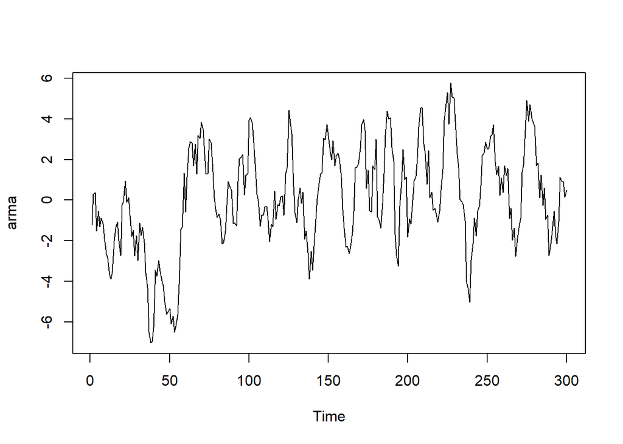

```r
ts.plot(arma)
```

Berdasarkan plot time series tersebut, dapat dilihat bahwa data proses ARMA(2,2) yang telah dibangkitkan stasioner dalam rataan.

### Plot ACF

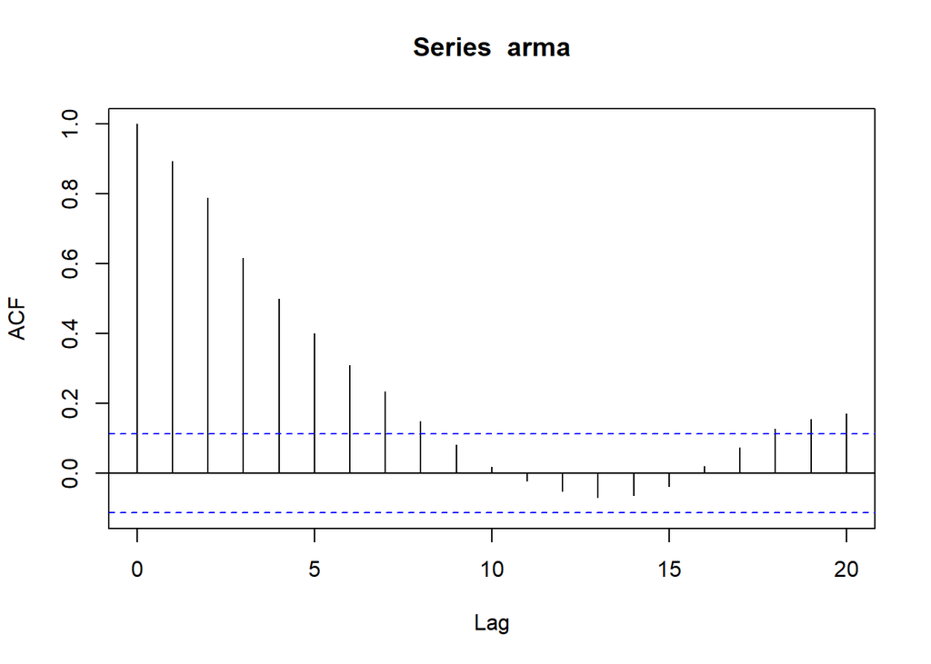

```r
acf(arma,lag.max = 20)
```

Berdasarkan plot ACF yang disajikan, terlihat bahwa plot ACF cenderung tails off membentuk pola grafik sinus yang perlahan mengecil.

### Plot PACF

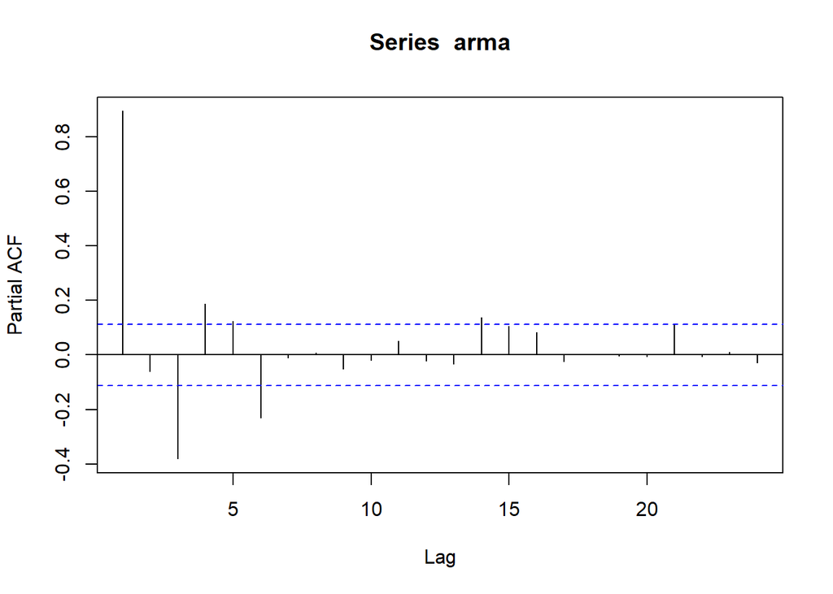

```r
pacf(arma)
```

Berdasarkan plot PACF diatas, terlihat bahwa plot PACF mengalami tails off dengan pola sinus yang perlahan mengecil. Berdasarkan plot ACF dan PACF, maka data ARMA(2,2) stasioner.

### Plot EACF

```r
TSA::eacf(arma)
```

```
AR/MA
  0 1 2 3 4 5 6 7 8 9 10 11 12 13
0 x x x x x x x x o o o  o  o  o
1 o x o o o o x o o o o  o  o  o
2 x x o o o o x o o o o  o  o  o
3 x x o x o o x o o o o  o  o  o
4 x x x x o o x o o o o  o  o  o
5 x x x x x x x o o o o  o  o  o
6 o o x o x x o o o o o  o  o  o
7 o o x o x x o x o o o  o  o  o
```

Berdasarkan pola segitiga nol pada plot EACF, dapat digambarkan bahwa segitiga nol condong berada pada ordo AR(1) dan MA(2).

## Scatterplot dan Korelasi Antar Lag

### Scatterplot dan Korelasi antara $Y_t$ dengan $Y_{t-1}$

```r
yt_arma <- arma[-1] #Yt
yt_1_arma <- arma[-300] #Yt-1
```

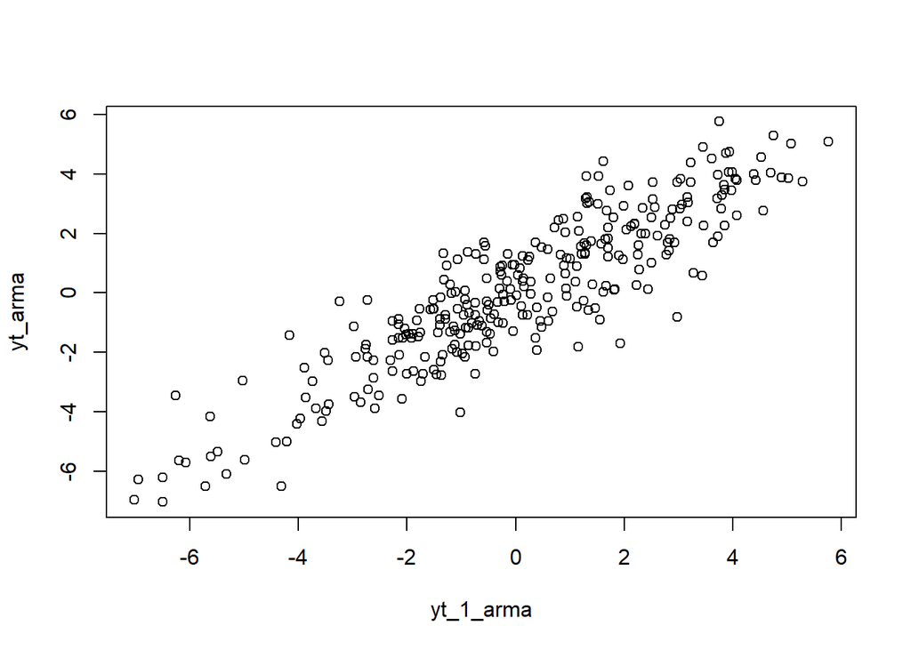

```r
plot(y=yt_arma,x=yt_1_arma)
```

Berdasarkan scatterplot tersebut, terlihat bahwa terdapat hubungan positif yang sangat kuat antara $Y_t$ dengan $Y_{t-1}$.

```r
cor(yt_arma,yt_1_arma)
```

```
[1] 0.8946787
```

Korelasi antara $Y_t$ dengan $Y_{t-1}$ dari hasil simulasi adalah 0.8947.

### Scatterplot dan Korelasi antara $Y_t$ dengan $Y_{t-2}$

```r
yt_arma2 <- arma[-c(1,2)] #Yt
yt_2_arma <- arma[-c(299,300)] #Yt-2
```

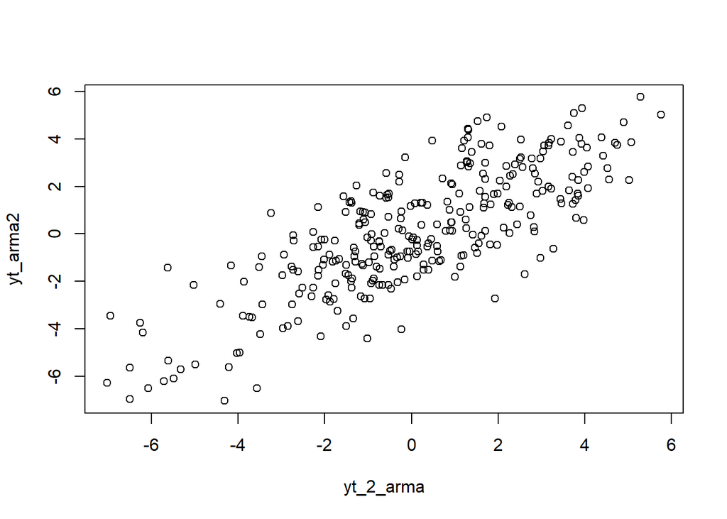

```r
plot(y=yt_arma2,x=yt_2_arma)
```

Berdasarkan scatterplot tersebut, terlihat bahwa terdapat hubungan positif yang kuat antara $Y_t$ dengan $Y_{t-2}$.

```r
cor(yt_arma2,yt_2_arma)
```

```
[1] 0.78822
```

Korelasi antara $Y_t$ dengan $Y_{t-2}$ dari hasil simulasi adalah 0.7882.

### Scatterplot dan Korelasi antara $Y_t$ dengan $Y_{t-3}$

```r
yt_arma3 <- arma[-c(1,2,3)] #Yt
yt_3_arma <- arma[-c(298,299,300)] #Yt-3
```

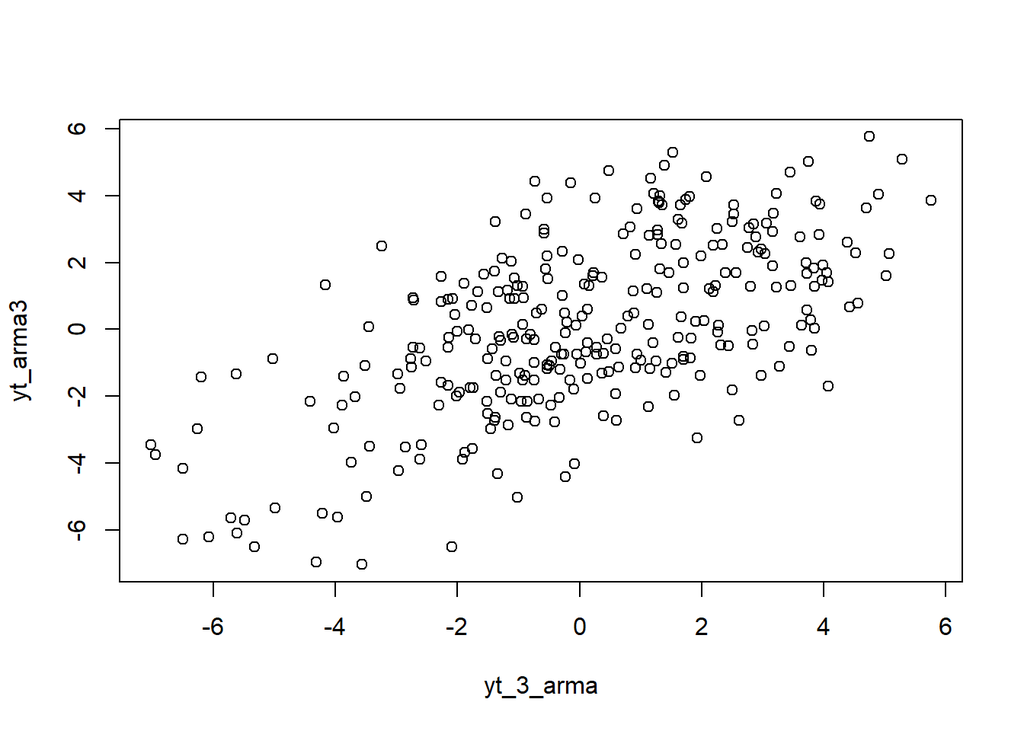

```r
plot(y=yt_arma3,x=yt_3_arma)
```

Berdasarkan scatterplot tersebut, terlihat bahwa terdapat hubungan positif yang kuat antara $Y_t$ dengan $Y_{t-3}$.

```r
cor(yt_arma3,yt_3_arma)
```

```
[1] 0.6177423
```

Korelasi antara $Y_t$ dengan $Y_{t-3}$ dari hasil simulasi adalah 0.6177.

### Perhitungan Korelasi Peubah Lag Teoritis

Selanjutnya, akan dilakukan perhitungan korelasi teoritis untuk masing-masing lag 1,2 dan 3 yang akan mendekati nilai korelasi simulasi dengan menggunakan persamaan $\rho_k=\gamma_k/\gamma_0$. Adapun, persamaan untuk mendapatkan nilai $\gamma_k$ adalah sebagai berikut:

$$\begin{cases}
\gamma_0 - \phi_1 \gamma_1 - \phi_2 \gamma_2 = (1 + \theta_1^2 + \theta_2^2)\sigma^2, \\[6pt]
\gamma_1 - \phi_1 \gamma_0 - \phi_2 \gamma_1 = (\theta_1 + \theta_1 \theta_2)\sigma^2, \\[6pt]
\gamma_2 - \phi_1 \gamma_1 - \phi_2 \gamma_0 = \theta_2 \sigma^2,
\\[6pt]
\gamma_k = \phi_1\gamma_{k-1} + \phi_2\gamma_{k-2}
\end{cases}$$

```r
phi1 <- 0.5; phi2 <- 0.2
theta1 <- 0.4; theta2 <- 0.6
sigma2 <- 1

A <- matrix(c(1, -phi1, -phi2,
              -phi1, 1-phi2, 0,
              -phi2, -phi1, 1), nrow=3, byrow=TRUE)
b <- c(1 + theta1^2 + theta2^2,
       theta1 + theta1*theta2,
       theta2) * sigma2

gamma012 <- solve(A, b)
gamma0 <- gamma012[1]; gamma1 <- gamma012[2]; gamma2 <- gamma012[3]

K <- 30
gamma <- numeric(K+1)
gamma[1] <- gamma0      # gamma_0
gamma[2] <- gamma1      # gamma_1
gamma[3] <- gamma2      # gamma_2
for(k in 4:(K+1)){
  gamma[k] <- phi1 * gamma[k-1] + phi2 * gamma[k-2]
}
rho <- gamma / gamma[1]
print(round(rho[2:4], 4))
```

```
[1] 0.8458 0.7884 0.5634
```

Secara teoritis, hasil perhitungan korelasi untuk lag 1 adalah 0.8458, untuk lag 2 adalah 0.7884 dan untuk lag 3 adalah 0.5634.